# Modelos SARIMA y ARIMAX

Extensión del modelo ARIMA

Curso de Series de Tiempo

## ARIMA Estacional: SARIMA

Un modelo ARIMA estacional (SARIMA) se forma incluyendo términos estacionales adicionales en los modelos ARIMA que hemos visto hasta ahora. Se escribe de la siguiente manera:

$$ARIMA(p,d,q) \times (P,D,Q)_m$$

donde:

- $(p,d,q)$ = componente no estacional
- $(P,D,Q)$ = componente estacional
- $m$ = período estacional por año (12 para mensual, 4 para trimestral)

La parte estacional del modelo consiste en términos que son similares a los componentes no estacionales del modelo, pero que involucran desplazamientos hacia atrás (backshifts) del periodo estacional.

**Ejemplo**: $ARIMA(1,1,1)(1,1,1)_4$ sin contaste para datos trimestrales (m = 4) tenemos el siguiente modelo :

$$(1 - \phi_{1}L)(1 - \Phi_{1}L^{4}) (1 - L)(1 - L^{4})y_{t} = (1 + \theta_{1}L)(1 + \Theta_{1}L^{4})\varepsilon_{t}.$$

- Los términos estacionales adicionales simplemente se multiplican por los términos no estacionales.

## ACF/PACF en modelos SARIMA

- La parte estacional de un modelo AR o MA se verá reflejada en los rezagos estacionales de la PACF y la ACF. Por ejemplo, un modelo ARIMA(0,0,0)(0,0,1)12 mostrará:
  - Un pico en el rezago 12 en la ACF, pero ningún otro pico significativo;
  - Un decaimiento exponencial en los rezagos estacionales de la PACF (es decir, en los rezagos 12, 24, 36, …).
- Del mismo modo, un modelo ARIMA(0,0,0)(1,0,0)12 mostrará:
  - Un decaimiento exponencial en los rezagos estacionales de la ACF;
  - Un único pico significativo en el rezago 12 de la PACF.
- Al considerar los órdenes estacionales apropiados para un modelo ARIMA estacional, **realice la diferenciación del rezago estacional**.

$$\Delta y_{t, 12} = y_{t, 12} - y_{t - 1, 12}$$

- El procedimiento de modelado es casi el mismo que para los datos no estacionales, excepto que necesitamos seleccionar términos AR y MA estacionales, así como los componentes no estacionales del modelo.

## Ejemplo 1. Empleo mensual en el sector de ocio y hostelería en EE. UU

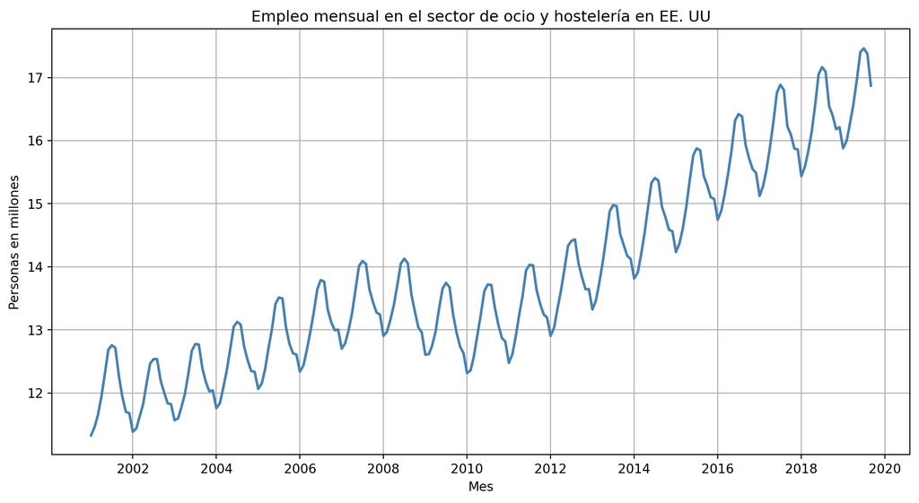

```python
import pandas as pd
import numpy as np
import matplotlib.pyplot as plt

datos = pd.read_csv("../data/us_employment.csv", parse_dates=["ds"])
datos = datos.loc[(datos["ds"] >= "2001-01-01") & (datos["unique_id"] == "Leisure and Hospitality")].reset_index(drop=True)
datos["y"] = datos["y"] / 1e3
datos = datos.set_index('ds')
datos.index = pd.DatetimeIndex(datos.index).to_period('M').to_timestamp()

fig, ax = plt.subplots(figsize=(12, 6))
ax.plot(datos.index, datos["y"], color='steelblue', linewidth=2)
ax.set_title('Empleo mensual en el sector de ocio y hostelería en EE. UU')
ax.set_xlabel('Mes')
ax.set_ylabel('Personas en millones')
ax.grid()
plt.show()
```

## Ejercicio 2. Tarea para la casa

Considera `aus_arrivals.csv` (está en la carpeta datos del repositorio en github), el número trimestral de visitantes internacionales a Australia desde varios países para el periodo 1981 Q1 – 2012 Q3. - Selecciona los viajas hacia Estados Unidos (US) y describe el gráfico de tiempo. - Estima el mejor modelo SARIMA y realiza el pronostico a 3 años. - Escribe la ecuación final del modelo.

## Ejercicio 3: Ventas de medicamentos corticosteroides en Australia

- Para nuestro tercer ejemplo, intentaremos pronosticar las ventas mensuales de medicamentos corticosteroides en Australia. Estos se conocen como fármacos H02 bajo el sistema de clasificación Anatómica, Terapéutica y Química.
- Datos: `PBS_unparsed`. Filtrar ATC2 == “H02”.

## ARIMAX: Modelos con Variables Exógenas

- Los modelos de series temporales anteriores permiten incluir información proveniente de observaciones pasadas de una serie, pero no permiten incorporar otra información que también puede ser relevante.
- Por ejemplo, los efectos de días festivos, la actividad de competidores, cambios en la legislación, la situación económica general u otras variables externas pueden explicar parte de la variación histórica y conducir a pronósticos más precisos.
- Usualmente realizaríamos este modelo :
  $$y_t = \beta_0 + \beta_1 x_{1,t} + \dots + \beta_k x_{k,t} + \varepsilon_t \\
  \varepsilon_t \sim WN$$

## Modelo ARIMAX

- El modelo ARIMAX extiende el modelo ARIMA para incluir otras variables que mejore la capacidad del modelo en el pronóstico.

**Casos de uso**: - Incorporar variables explicativas (precio, temperatura, etc.) - Análisis de impacto de políticas - Eventos especiales (días festivos)

- Sin embargo, los residuos un modelo inicial entre $y_t$ y $x_t$ tiene un problema de autocorrelación. **El modelo ARIMA explicitamente modela la autocorrelación y es aplicado en el término de error del modelo.**
- Para ello los errores del modelo entre $y_t$ y $x_t$ es reemplazado por $\eta_t$ que tiene autocorrelación.
- Esta autocorrelación es modelada por ARIMA y los errores $\varepsilon_t$ son $WN$.
  $$y_t = \beta_0 + \beta_1 x_{1,t} + \dots + \beta_k x_{k,t} + \eta_t \\
  (1-\phi_1B)(1-B)\eta_t = (1+\theta_1B)\varepsilon_t \\
  \varepsilon_t \sim WN$$
- Cuando estimamos los parámetros del modelo, necesitamos minimizar la suma de los valores de $\varepsilon_t^2$. Si minimizamos, en cambio, la suma de los valores de $\eta_t^2$ (que es lo que ocurriría si estimáramos el modelo de regresión ignorando las autocorrelaciones en los errores) los estimadores son inconsistentes.

Todas las variables de un modelo de regresión con errores ARMA deben ser estacionarias antes de estimarlo. Por lo tanto, primero se debe verificar que $y_t$ y todos los predictores $x_{1,t}, \ldots, x_{k,t}$ sean estacionarios. Si se estima el modelo cuando alguna de estas variables es no estacionaria, los coeficientes obtenidos no serán estimadores consistentes (y, por lo tanto, pueden no ser significativos).

## Ejemplo 1 : El modelo macroeconómico del crecimiento del consumo en Estados Unidos

- Queremos modelar cómo cambia el consumo real (compra de bienes y servicios) de una economía según el incremento del ingreso.
  $$\Delta C_t = \beta_0 + \beta_1 \Delta Ingreso_t + \varepsilon_t$$
- $\Delta C_t$ es el cambio porcentual en el gasto real de consumo personal.
- $Ingreso_t$ es el cambio porcentual en el ingreso personal real disponible.
- Usar el archivo `US_change.csv` para modelar.